# Bat Foraging Calls

M. Roberts

2025-09-26

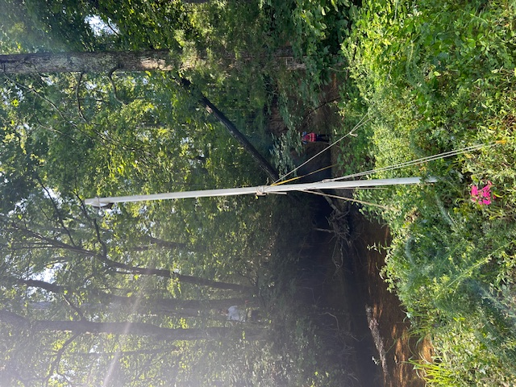

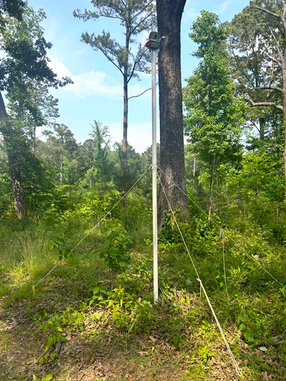

For my thesis project, I set out acoustics across Fort Campbell Military Base and collected bat calls over 8 days. My field technicians and I completed habitat assessments for each acoustic placed and recorded characteristics such as vegetation cover, mean canopy cover, basal area, snags, water presence, etc. For this mixed-models example, I am going to examine the three vegetation covers I recorded, hardwood, softwood, and mixed, at 19 acoustic locations and see if that fixed effect has an influence on foraging calls. A poisson distribution was used throughout my example due to calls being counts throughout the night.

I added some static maps to visualize the deployment locations for my acoustics. For my first map I used the National Land Cover Database (NLCD) to observe land cover. This imagery visualizes urbanization areas as well as vegetation cover. These maps will tie in to these models as I looked at different vegetation types.

```r
points <- read.csv("habitat_data.csv")
points <- points %>%
                select(site_id, latitude, longitude)
points <- points[points$site_id != "44a",]
points <- st_as_sf(points, coords = c("longitude", "latitude"), crs = 4326)

mil <- st_read("tl_2022_us_mil.shp")
```

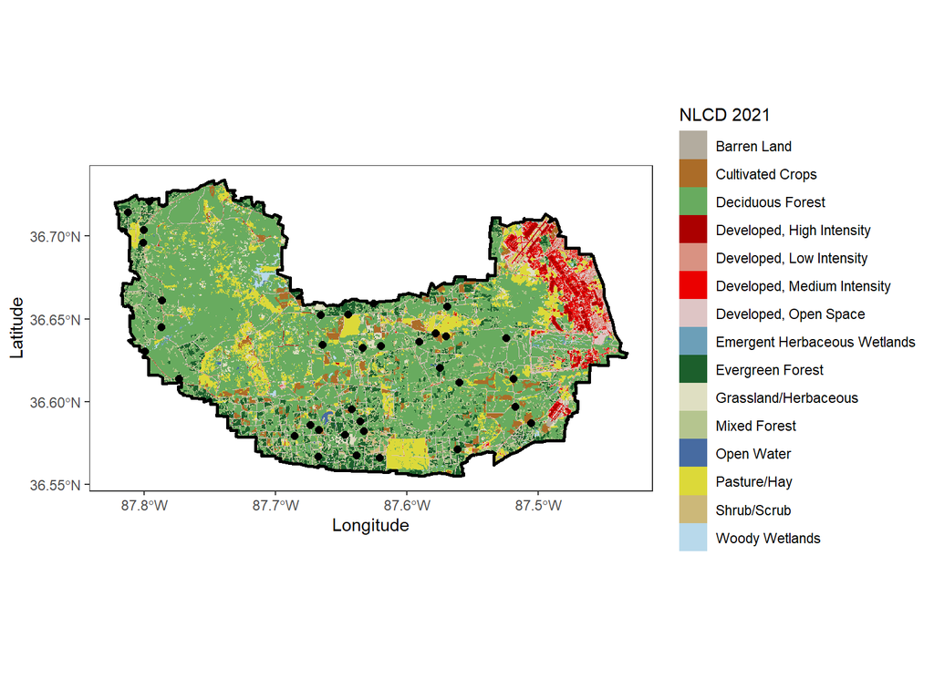

```r
fc <- mil[mil$FULLNAME == "Ft Campbell" | grepl("Campbell", mil$FULLNAME), ]

nlcd <- rast("nlcd_2021_fortcampbell.tif")

fc_vec <- vect(fc)
fc_vec <- project(fc_vec, nlcd)

nlcd_crop <- mask(crop(nlcd, fc_vec), fc_vec)

nlcd_df <- as.data.frame(nlcd_crop, xy = TRUE)
colnames(nlcd_df) <- c("x", "y", "landcover")

points_vec <- vect(points)
points_vec <- project(points_vec, nlcd_crop)

fc <- st_transform(fc, crs(nlcd_crop))
points <- st_transform(points, crs(nlcd_crop))

nlcd_df$landcover_names <- recode(nlcd_df$landcover,
                                   `11` = "Open Water",
                                   `12` = "Perennial Ice/Snow",
                                   `21` = "Developed, Open Space",
                                   `22` = "Developed, Low Intensity",
                                   `23` = "Developed, Medium Intensity",
                                   `24` = "Developed, High Intensity",
                                   `31` = "Barren Land",
                                   `41` = "Deciduous Forest",
                                   `42` = "Evergreen Forest",
                                   `43` = "Mixed Forest",
                                   `52` = "Shrub/Scrub",
                                   `71` = "Grassland/Herbaceous",
                                   `81` = "Pasture/Hay",
                                   `82` = "Cultivated Crops",
                                   `90` = "Woody Wetlands",
                                   `95` = "Emergent Herbaceous Wetlands"
                                  )

ggplot() +
  geom_raster(data = nlcd_df, aes(x = x, y = y, fill = factor(landcover_names))) +
  xlab("Longitude") +
  ylab("Latitude")+
  geom_sf(data = fc, fill = NA, color = "#000000", size = 1) +
  geom_sf(data = points, color = "black", size = 2) +
  scale_fill_manual(
    values = c(
      "Open Water" = "#476ba1",
      "Perennial Ice/Snow" = "#d1def1",
      "Developed, Open Space" = "#dec5c5",
      "Developed, Low Intensity" = "#d99282",
      "Developed, Medium Intensity" = "#eb0000",
      "Developed, High Intensity" = "#ab0000",
      "Barren Land" = "#b3ac9f",
      "Deciduous Forest" = "#68ab5f",
      "Evergreen Forest" = "#1c5f2c",
      "Mixed Forest" = "#b5c58f",
      "Shrub/Scrub" = "#ccb879",
      "Grassland/Herbaceous" = "#dfdfc2",
      "Pasture/Hay" = "#dcd939",
      "Cultivated Crops" = "#ab6c28",
      "Woody Wetlands" = "#b8d9eb",
      "Emergent Herbaceous Wetlands" = "#6c9fb8"
    ), name = "NLCD 2021" ) +
  theme_bw() +
  theme(panel.grid.major = element_blank(),
               panel.grid.minor = element_blank())
```

For my second map, I used the 2020 North American Lond Cover data set from the North American Land Change Monitoring System (NALCMS). I decided to use both of these maps, as the first one shows in-depth urbanization levels while this one provides more specific land cover descriptions.

```r
points <- read.csv("habitat_data.csv")
points <- points %>%
                select(site_id, latitude, longitude)
points <- points[points$site_id != "44a",]
points <- st_as_sf(points, coords = c("longitude", "latitude"), crs = 4326)

mil <- st_read("tl_2022_us_mil.shp")
```

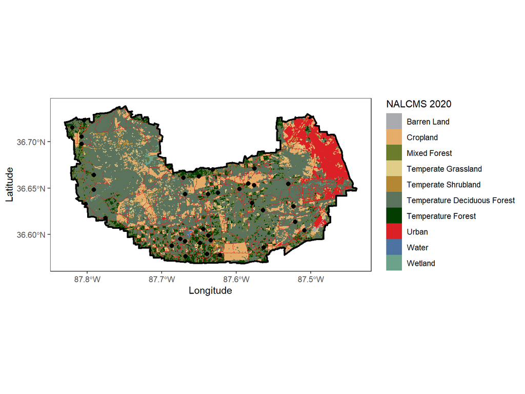

```r
fc <- mil[mil$FULLNAME == "Ft Campbell" | grepl("Campbell", mil$FULLNAME), ]

lc <- rast("landcover_2020_fortcampbell.tif")

fc_vec <- vect(fc)
fc_vec <- project(fc_vec, lc)

lc_crop <- mask(crop(lc, fc_vec), fc_vec)

lc_df <- as.data.frame(lc_crop, xy = TRUE)
colnames(lc_df) <- c("x", "y", "landcover")

points_vec <- vect(points)
points_vec <- project(points_vec, lc_crop)

fc <- st_transform(fc, crs(lc_crop))
points <- st_transform(points, crs(lc_crop))

lc_df$landcover_names <- recode(lc_df$landcover,
                                    `1` = "Temperature Forest",
                                    `2` = "Sub-polar Taiga Forest",
                                    `3` = "Evergreen Forest",
                                    `4` = "Tropical Deciduous Forest",
                                    `5` = "Temperature Deciduous Forest",
                                    `6` = "Mixed Forest",
                                    `7` = "Tropical Shrubland",
                                    `8` = "Temperate Shrubland",
                                    `9` = "Tropical Grassland",
                                    `10` = "Temperate Grassland",
                                    `11` = "Sub-polar Shrubland Moss",
                                    `12` = "Sub-polar Grassland",
                                    `13` = "Sub-polar Barren",
                                    `14` = "Wetland",
                                    `15` = "Cropland",
                                    `16` = "Barren Land",
                                    `17` = "Urban",
                                    `18` = "Water",
                                    `19` = "Snow"
                               )

ggplot() +
  geom_raster(data = lc_df, aes(x = x, y = y, fill = factor(landcover_names))) +
  xlab("Longitude") +
  ylab("Latitude")+
  geom_sf(data = fc, fill = NA, color = "#000000", size = 1) +
  geom_sf(data = points, color = "black", size = 2) +
  scale_fill_manual(
    values = c(
      "Temperature Forest" = "#033e00",
      "Sub-polar Taiga Forest" = "#939b71",
      "Evergreen Forest" = "#196d12",
      "Tropical Deciduous Forest" = "#1fab01",
      "Temperature Deciduous Forest" = "#5b725c",
      "Mixed Forest" = "#6b7d2c",
      "Tropical Shrubland" = "#b29d29",
      "Temperate Shrubland" = "#b48833",
      "Tropical Grassland" = "#e9da5d",
      "Temperate Grassland" = "#e0cd88",
      "Sub-polar Shrubland Moss" = "#a07451",
      "Sub-polar Grassland" = "#bad292",
      "Sub-polar Barren" = "#3f8970",
      "Wetland" = "#6ca289",
      "Cropland" = "#e6ad6a",
      "Barren Land" = "#a9abae",
      "Urban" = "#db2126",
      "Water" = "#4c73a1",
      "Snow" = "#fff7fe"
    ), name = "NALCMS 2020" ) +
  theme_bw() +
  theme(panel.grid.major = element_blank(),
               panel.grid.minor = element_blank())
```

Let’s read in our data set and look at vegetation cover as our fixed effect while looking at vegetation cover and site ID as our random effects.

```r
ad <- read.csv("acoustics.data.csv")

ad1 <- glmer(num_calls ~ veg_cover + (veg_cover | site_id), family=poisson(), data=ad)
summary(ad1)
```

```
## Generalized linear mixed model fit by maximum likelihood (Laplace
##   Approximation) [glmerMod]
##  Family: poisson  ( log )
## Formula: num_calls ~ veg_cover + (veg_cover | site_id)
##    Data: ad
##
##       AIC       BIC    logLik -2*log(L)  df.resid
##    5382.7    5407.1   -2682.4    5364.7       102
##
## Scaled residuals:
##      Min       1Q   Median       3Q      Max
## -18.0988  -1.4681  -0.3253   1.3374  31.5268
##
## Random effects:
##  Groups  Name              Variance Std.Dev. Corr
##  site_id (Intercept)       2.716    1.6480
##          veg_covermixed    0.292    0.5404   -0.74
##          veg_coversoftwood 2.716    1.6480   -1.00  0.74
## Number of obs: 111, groups:  site_id, 19
##
## Fixed effects:
##                   Estimate Std. Error z value Pr(>|z|)
## (Intercept)         2.1856     0.4461   4.899 9.62e-07 ***
## veg_covermixed      1.1892     0.7991   1.488 0.136694
## veg_coversoftwood   1.7339     0.4489   3.862 0.000112 ***
## ---
## Signif. codes:  0 '***' 0.001 '**' 0.01 '*' 0.05 '.' 0.1 ' ' 1
##
## Correlation of Fixed Effects:
##             (Intr) vg_cvrm
## veg_covrmxd -0.558
## vg_cvrsftwd -0.994  0.555
## optimizer (Nelder_Mead) convergence code: 0 (OK)
## boundary (singular) fit: see help('isSingular')
```

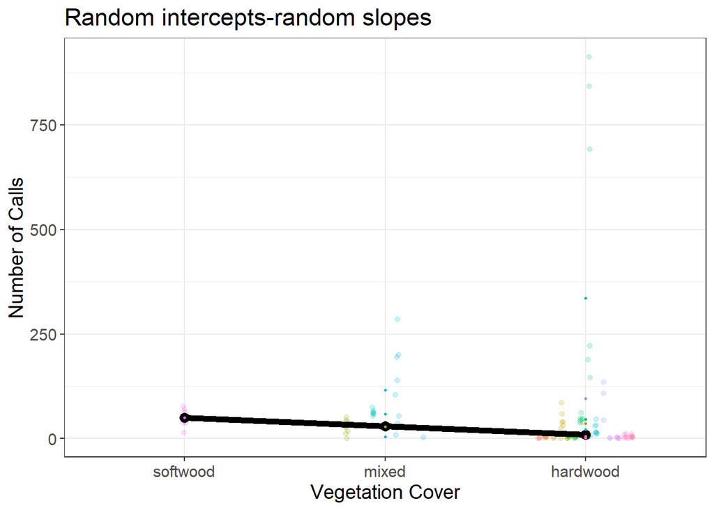

```r
flexplot::visualize(ad1, plot="model", sample=19) +
  ggtitle("Random intercepts-random slopes") +
  xlab("Vegetation Cover") +
  ylab("Number of Calls")
```

This summary concluded that the hardwood and softwood vegetation cover has significance in foraging calls (p < 0.05) . It’s worth taking a look at the same fixed effect, vegetation cover, but only using site ID as a random effect.

```r
ad2 <- glmer(num_calls ~ veg_cover + (1|site_id), family=poisson(), data=ad)
summary(ad2)
```

```
## Generalized linear mixed model fit by maximum likelihood (Laplace
##   Approximation) [glmerMod]
##  Family: poisson  ( log )
## Formula: num_calls ~ veg_cover + (1 | site_id)
##    Data: ad
##
##       AIC       BIC    logLik -2*log(L)  df.resid
##    5379.9    5390.7   -2686.0    5371.9       107
##
## Scaled residuals:
##      Min       1Q   Median       3Q      Max
## -18.0982  -1.4685  -0.3279   1.3304  31.5290
##
## Random effects:
##  Groups  Name        Variance Std.Dev.
##  site_id (Intercept) 2.365    1.538
## Number of obs: 111, groups:  site_id, 19
##
## Fixed effects:
##                   Estimate Std. Error z value Pr(>|z|)
## (Intercept)         2.1912     0.4169   5.256 1.47e-07 ***
## veg_covermixed      1.1613     0.8832   1.315    0.189
## veg_coversoftwood   1.7270     1.5939   1.084    0.279
## ---
## Signif. codes:  0 '***' 0.001 '**' 0.01 '*' 0.05 '.' 0.1 ' ' 1
##
## Correlation of Fixed Effects:
##             (Intr) vg_cvrm
## veg_covrmxd -0.471
## vg_cvrsftwd -0.262  0.123
```

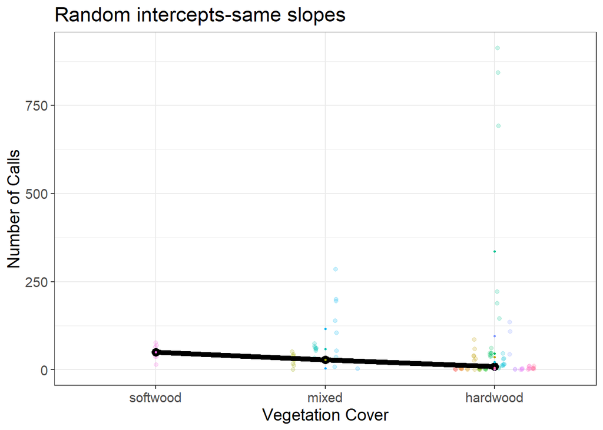

```r
flexplot::visualize(ad2, plot="model", sample=19) +
  ggtitle("Random intercepts-same slopes") +
  xlab("Vegetation Cover") +
  ylab("Number of Calls")
```

```r
results <- parameters::compare_parameters(ad1, ad2, select = "{estimate}<br>({se})|{p}")
print_html(results)
```

| Parameter | ad1 Log-Mean(SE) | ad1 p | ad2 Log-Mean(SE) | ad2 p |
| --- | --- | --- | --- | --- |
| (Intercept) | 2.19 (0.45) | <0.001 | 2.19 (0.42) | <0.001 |
| veg cover (mixed) | 1.19 (0.80) | 0.137 | 1.16 (0.88) | 0.189 |
| veg cover (softwood) | 1.73 (0.45) | <0.001 | 1.73 (1.59) | 0.279 |
| Observations | 111 |  | 111 |  |

```r
arm::display(ad1)
```

```
## glmer(formula = num_calls ~ veg_cover + (veg_cover | site_id),
##     data = ad, family = poisson())
##                   coef.est coef.se
## (Intercept)       2.19     0.45
## veg_covermixed    1.19     0.80
## veg_coversoftwood 1.73     0.45
##
## Error terms:
##  Groups   Name              Std.Dev. Corr
##  site_id  (Intercept)       1.65
##           veg_covermixed    0.54     -0.74
##           veg_coversoftwood 1.65     -1.00  0.74
##  Residual                   1.00
## ---
## number of obs: 111, groups: site_id, 19
## AIC = 5382.7, DIC = 4131.4
## deviance = 4748.1
```

```r
arm::display(ad2)
```

```
## glmer(formula = num_calls ~ veg_cover + (1 | site_id), data = ad,
##     family = poisson())
##                   coef.est coef.se
## (Intercept)       2.19     0.42
## veg_covermixed    1.16     0.88
## veg_coversoftwood 1.73     1.59
##
## Error terms:
##  Groups   Name        Std.Dev.
##  site_id  (Intercept) 1.54
##  Residual             1.00
## ---
## number of obs: 111, groups: site_id, 19
## AIC = 5379.9, DIC = 4124.1
## deviance = 4748.0
```

```r
performance::compare_performance(ad1, ad2)
```

```
## # Comparison of Model Performance Indices
##
## Name |    Model |  AIC (weights) | AICc (weights) |  BIC (weights) |    RMSE
## ----------------------------------------------------------------------------
## ad1  | glmerMod | 5382.7 (0.195) | 5384.5 (0.107) | 5407.1 (<.001) | 104.160
## ad2  | glmerMod | 5379.9 (0.805) | 5380.3 (0.893) | 5390.7 (>.999) | 104.160
##
## Name | Sigma | Score_log | Score_spherical | R2 (cond.) | R2 (marg.) |   ICC
## ----------------------------------------------------------------------------
## ad1  |     1 |   -23.684 |           0.060 |            |            |
## ad2  |     1 |   -23.684 |           0.060 |      0.993 |      0.138 | 0.991
```

From this comparison model, my second model (ad2) is better to use. As of now, my sample size is small, so this conclusion might change, but for now the only random effect that is worth noting would be site ID. Ad2 has a lower AIC than ad1 indicating that ad2 is a better fit model.